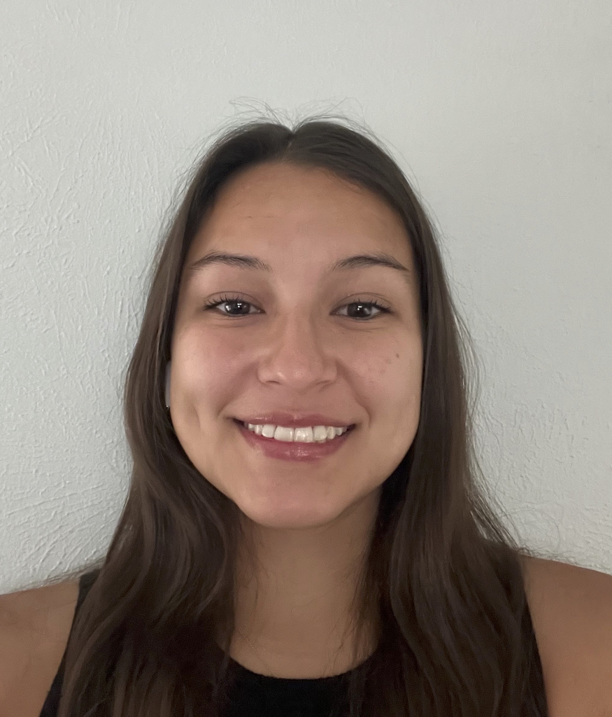

# Caroline Mazariegos

## Bio

I am a recent graduate from Simmons University, holding a double major in Data Science and Analytics and Statistics, with a minor in Public Health. I am passionate about using data analysis and machine learning on global healthcare data to develop innovative solutions for real-world problems. My academic journey has equipped me with a robust set of data science skills, demonstrated through my various coursework and projects. I am particularly interested in using machine learning techniques to uncover insights and drive decision-making in healthcare.

## Education

**Simmons University** | Boston, MA

B.S. Data Science and Analytics & Statistics | August 2020 - May 2024

```
  - Minor: Public Health

  - Summa Cum Laude

  - Honors Program
```

## Experience

**Research Data Coder** | Brigham and Women’s Hospital | January 2022 - Present

**Global Technology Analyst** | Bank of America | June 2023 - August 2023

**Data Entry Intern** | Broadstreet Institute | January 2022 - March 2022

## Relevant Courses

- **Introduction to Computer Science** | Fall 2021
- **Intermediate Statistics: Design & Analysis** | Fall 2021
- **Data Structures** | Spring 2022
- **Introduction to Data Science** | Spring 2022
- **Data Interoperability** | Fall 2022
- **Special Topics (Time Series)** | Spring 2023
- **Regression Models** | Spring 2023
- **Machine Learning** | Spring 2024

## Machine Learning Algorithms

- **Simple Rules (1Rule)**
- **Naive Bayes**
- **Linear Regression**
- **Logistic Regression**
- **KNN**
- **Association Rules**
- **Decision Trees**
- **K Clustering**
- **PCA**
- **ANN**
- **Random Forests**
- **Boosting**
- **Neural Networks**
- **SVM**

## Relevant Coursework

**Intro to Data Science -** *Blogs*

1. **Do You Like to Dance?** | February 2022
2. **Data Wrangling 101** | April 2022
3. **Save The Bees!** | May 2022

**Data Interoperability -** *Use Case*

1. **College Majors and Their Graduates** | December 2022

**Special Topics (Time Series) -** *Final Project*

1. **Droughts in U.S.** | May 2023

**Machine Learning -** *Final Project*

1. **Obesity Levels Based on Eating Habits and Physical Condition** | May 2024